# **Project Introduction**

Our project consists of 2 milestones.  
**milestone 1:** Detect license plates from videos and blur them.  
**milestone 2:** Try to replace the detected license plate with a fake one.

We will first tried to detect license plates from images by training *YOLO(You Only Look Once)* model on a dataset of license plates. We used yolov3 and yolov5 for this purpose.  
This notebook is for the yolov5 model. here two datasets are explored and used for training the model. The first dataset is from kaggle<sup>[1]</sup> consisting of 433 images of cars with license plates. The second dataset is CCPD(Chinese City Parking Dataset) <sup>[2]</sup> consisting of more than 250k images of license plates.  
More details such as annotations, nature of the images in datasets and etc are discussed as we explore them.

references:

1. https://www.kaggle.com/datasets/andrewmvd/car-plate-detection
2. https://github.com/detectRecog/CCPD

# **Directory Structure**

```
├── datasets
│   ├── CCPD2019
│   ├── dataset1
├── test_videos
├── yolov5
├── best_3_ccpd.pt
├── best_100.pt
├── cars.yaml
├── ccpd.yaml
├── processBatch.py
├── train.ipynb (this notebook)
```

note: This directory structure isn't deep and doesn't include the environment, **pycache**, some yolov runtime generated files and etc.

# **Necessary imports**

```python
# required to traverse the xml files and extract the bounding boxes
from glob import glob
import xml.etree.ElementTree as xet

import pandas as pd
import cv2
import os
import shutil

import torch
import torchvision

from PIL import Image
%matplotlib inline
import matplotlib.pyplot as plt
```

#### Installed suitable version of pytorch library for using with my GPU from [pytorch.org](https://pytorch.org/get-started/locally/)

| Name | specifications |
| --- | --- |
| Cuda Device | Nvidia GeForce RTX 3070 mobile |
| Cuda Cores: | 5120 |
| Memory: | 8GB GDDR6 |
| FP32 (float) | 15.97 TFLOPS |
| FP64 (double) | 249.6 GFLOPS (1:64) |

Note: This device isn't intended for any professional/academic use. It's more of a gaming device.

```python
# proper pip installation from pytorch.org
# !pip3 install torch torchvision torchaudio --extra-index-url https://download.pytorch.org/whl/cu117
```

```python
# check cuda availability
print(f'cuda is available: {torch.cuda.is_available()}')

# check pytorch version
print(f"PyTorch Version:   {torch.__version__}")
```

```
cuda is available: True
PyTorch Version:   1.13.1+cu117
```

# **YOLOv5**

### **Clone the YOLOv5 repository from github and install the requirements**

```python
!git clone https://github.com/ultralytics/yolov5    # clone
!cd yolov5                                          # enter root directory
!pip install -r requirements.txt                    # install dependencies
```

### **Yolov5 Label Format (from documentation)**

yolo expects one *.txt file per image (if no objects in image, no* .txt file is required). The *.txt file specifications are:

- One row per object
- Each row is class x_center y_center width height format.
- Box coordinates must be in normalized xywh format (from 0 - 1). If your boxes are in pixels, divide x_center and width by image - - width, and y_center and height by image height.
- Class numbers are zero-indexed (start from 0).

[figure not shown]

- The label file corresponding to the above image contains 2 persons (class 0) and a tie (class 27):

> ```
> 0 0.481719 0.634028 0.690625 0.713278
> 0 0.741094 0.524306 0.314750 0.933389
> 27 0.364844 0.795833 0.078125 0.400000
> ```

**Note:** We will only be having one class in our dataset, so we will be using the same class number `0` for all the images.

### **Yolov5 dataset configuration file**

The dataset configuration file is a yaml file that contains the information about the dataset. It contains the following information:

- train: path to train images
- val: path to validation images
- nc: number of classes
- names: list of class names

Here is the configuration file for the dataset1(similar to the one for CCPD dataset as well): >

# **Kaggle dataset**

Dataset folder is named dataset1 in the datasets folder and have following structure:

```
├── dataset1
│   ├── annotations
│   ├── images
│   ├── labels
```

Some changes are done to the original download, such as dividing the images randomly into train, validation and test folders with 70:20:10 ratios, same for the labels.  
Though labels are aren't provided in the dataset are are derived from the annotations. *see the code below*.

### **Dataset format**

- data in annotations folder is in xml files. we need to convert it to txt files in the format required by YOLOv5.
- The xml file consists lots of information but the important ones are bounding box coordinates and image dimensions.
- The bounding box coordinates are in the format: `<xmin> <ymin> <xmax> <ymax>`

  ```
          ymax
            |
            |
            |
            |
  xmin --------------- xmax
            |
            |
            |
            |
            ymin
  ```

### **Converting necessary information from annotations to a dataframe**

```python
def create_labels_dataframe():
    cwd = os.getcwd()
    paths = glob(r'datasets\dataset1\annotations\*.xml')
    labels_dict = dict(filepath=[],tw=[],th=[],xmin=[],xmax=[],ymin=[],ymax=[])
    for filename in paths:

        info = xet.parse(filename)
        root = info.getroot()
        size_object = root.find('size')
        width = int(size_object.find('width').text)
        height = int(size_object.find('height').text)
        member_object = root.find('object')
        labels_info = member_object.find('bndbox')
        xmin = int(labels_info.find('xmin').text)
        xmax = int(labels_info.find('xmax').text)
        ymin = int(labels_info.find('ymin').text)
        ymax = int(labels_info.find('ymax').text)

        labels_dict['filepath'].append(cwd+"\\"+filename)
        labels_dict['tw'].append(width) # tw = total width
        labels_dict['th'].append(height) # th = total height
        labels_dict['xmin'].append(xmin)
        labels_dict['xmax'].append(xmax)
        labels_dict['ymin'].append(ymin)
        labels_dict['ymax'].append(ymax)

    return pd.DataFrame(labels_dict)
```

```python
df = create_labels_dataframe()
df
```

|  | filepath | tw | th | xmin | xmax | ymin | ymax |
| --- | --- | --- | --- | --- | --- | --- | --- |
| 0 | c:\Users\shiva\Desktop\UofT\Term4-winter2023\M... | 500 | 268 | 226 | 419 | 125 | 173 |
| 1 | c:\Users\shiva\Desktop\UofT\Term4-winter2023\M... | 400 | 248 | 134 | 262 | 128 | 160 |
| 2 | c:\Users\shiva\Desktop\UofT\Term4-winter2023\M... | 400 | 225 | 140 | 303 | 5 | 148 |
| 3 | c:\Users\shiva\Desktop\UofT\Term4-winter2023\M... | 400 | 267 | 175 | 214 | 114 | 131 |
| 4 | c:\Users\shiva\Desktop\UofT\Term4-winter2023\M... | 400 | 300 | 167 | 240 | 202 | 220 |
| ... | ... | ... | ... | ... | ... | ... | ... |
| 428 | c:\Users\shiva\Desktop\UofT\Term4-winter2023\M... | 600 | 400 | 278 | 407 | 182 | 263 |
| 429 | c:\Users\shiva\Desktop\UofT\Term4-winter2023\M... | 400 | 248 | 133 | 261 | 126 | 160 |
| 430 | c:\Users\shiva\Desktop\UofT\Term4-winter2023\M... | 400 | 300 | 98 | 297 | 102 | 191 |
| 431 | c:\Users\shiva\Desktop\UofT\Term4-winter2023\M... | 370 | 400 | 85 | 247 | 196 | 259 |
| 432 | c:\Users\shiva\Desktop\UofT\Term4-winter2023\M... | 375 | 500 | 70 | 262 | 198 | 271 |

433 rows × 7 columns

### **Testing the annotations**

[figure not shown]

```python
def show_image_with_bounding_box(bounding_box_test):
    img_path = os.path.join(os.getcwd(),"datasets","dataset1","images","train","Cars"+str(bounding_box_test)+".png")
    img = Image.open(img_path)
    # get the bounding box from the dataframe if filepath has Cars+bounding_box_test+.png in it, then also get the xmin,ymin,xmax,ymax into a list
    bounding_box = df[df['filepath'].str.contains("Cars"+str(bounding_box_test)+".xml")][['xmin','ymin','xmax','ymax']].values.tolist()
    bounding_box = bounding_box[0]
    rect = plt.Rectangle((bounding_box[0], bounding_box[1] ),bounding_box[2]-bounding_box[0],bounding_box[3]-bounding_box[1],fill=False,edgecolor='red',linewidth=1)
    plt.imshow(img)
    plt.gca().add_patch(rect)

show_image_with_bounding_box(2)
```

### **Dataset split ratios**

```python
images_file_path_main = os.path.join(os.getcwd(),"datasets","dataset1","images")

# loop through the images folder and folders inside it train, val, test and get the total number of images
total_images = 0
for folder in os.listdir(images_file_path_main):
    images_file_path = os.path.join(images_file_path_main,folder)
    # add to images only if the file is a png file
    total_images += len([name for name in os.listdir(images_file_path) if name.endswith(".png")])

print(f"Total images: {total_images}")

# divide images into 7:2:1 ratio
train_num = int(total_images*0.7)
val_num = int(total_images*0.2)
test_num = total_images - (train_num + val_num)

print(f"train: {train_num}, val: {val_num}, test: {test_num}")
```

```
Total images: 433
train: 303, val: 86, test: 44
```

### **Calculating the x_center, y_center, width and height**

- The x_center and y_center are calculated by the formula:  
  `x_center = (xmin + xmax)/(2*tw)`  
  `y_center = (ymin + ymax)/(2*th)`
- The width and height of the bounding box are calculated by the formula:  
  `width = (xmax - xmin)/tw`  
  `height = (ymax - ymin)/th`

note: where tw and th are the width and height of the image respectively.

```python
def calculate_xywh( tw, th, xmin,ymin,xmax,ymax):
    xc = (xmin+xmax)/2
    xc = xc/tw
    yc = (ymin+ymax)/2
    yc = yc/th
    w = xmax-xmin
    w = w/tw
    h = ymax-ymin
    h = h/th
    return xc,yc,w,h
```

### **Creating Labels (*.txt files)**

- the bounding box coordinates are converted to the required format by using the image dimensions.
- the class is 0 as there is only one class in the dataset.
- the labels are saved in the labels folder in the same format as the images in the images folder.
- the labels are saved in the same name as the image file with .txt extension.

```python
# create labels folder if it doesn't exist
labels_folder = 'datasets/dataset1/labels'
if not os.path.exists(labels_folder):
    os.makedirs(labels_folder)

if os.path.exists(labels_folder):
    # loop through the images folder and folders inside it train, val, test
    for folder in os.listdir(images_file_path_main):
        images_file_path = os.path.join(images_file_path_main,folder)
        # loop through the images in the train folder
        for image in os.listdir(images_file_path):
            # get the bounding box from the dataframe if filepath has image in it, then also get the xmin,ymin,xmax,ymax into a list
            bounding_box = df[df['filepath'].str.contains(image[:-4])][['tw','th','xmin','ymin','xmax','ymax']].values.tolist()
            bounding_box = bounding_box[0]
            # calculate the xc,yc,w,h
            xc,yc,w,h = calculate_xywh(*bounding_box)
            # create a file with the same name as the image and write the label and bounding box coordinates
            with open(os.path.join(labels_folder,folder,image.split(".")[0]+".txt"), "w") as f:
                f.write(f"0 {xc} {yc} {w} {h}")
```

### **Training the model**

Either bug or intended behavior, but jupyter notebook doesn't show the progress bar of the training process. So, I ran the training process in a terminal.  
The training process is done in the terminal using the following command:

> ```
> !python yolov5/train.py --img 640 --batch 4 --epochs 100 --data cars.yaml --weights yolov5s.pt --device 0
> ```

**parameters used:**

- `--img 640` : image size
- `--batch 4` : batch size
- `--epochs 100` : number of epochs
- `--data cars.yaml` : path to the dataset configuration file
- `--weights yolov5s.pt` : path to the pretrained weights
- `--device 0` : device to use for training (GPU here)

```python
!python yolov5/train.py --img 640 --batch 4 --epochs 100 --data cars.yaml --weights yolov5s.pt --device 0
```

### **Testing the model using detect.py script**

We will use the test images using yolov5 detect.py script.

```python
!python yolov5/detect.py --weights yolov5/runs/train/exp24/weights/best.pt --img 640 --conf 0.25 --source datasets/dataset1/images/test
```

```
detect: weights=['yolov5/runs/train/exp24/weights/best.pt'], source=datasets/dataset1/images/test, data=yolov5\data\coco128.yaml, imgsz=[640, 640], conf_thres=0.25, iou_thres=0.45, max_det=1000, device=, view_img=False, save_txt=False, save_conf=False, save_crop=False, nosave=False, classes=None, ag…
YOLOv5  v7.0-108-g4db6757 Python-3.10.4 torch-1.13.1+cu117 CUDA:0 (NVIDIA GeForce RTX 3070 Laptop GPU, 8192MiB)

Fusing layers...
Model summary: 157 layers, 7012822 parameters, 0 gradients, 15.8 GFLOPs
image 1/44 C:\Users\shiva\Desktop\UofT\Term4-winter2023\MIE1517\Project\Testing\datasets\dataset1\images\test\Cars389.png: 480x640 1 license_plate, 22.2ms
image 2/44 C:\Users\shiva\Desktop\UofT\Term4-winter2023\MIE1517\Project\Testing\datasets\dataset1\images\test\Cars390.png: 480x640 2 license_plates, 16.5ms
image 3/44 C:\Users\shiva\Desktop\UofT\Term4-winter2023\MIE1517\Project\Testing\datasets\dataset1\images\test\Cars391.png: 384x640 1 license_plate, 17.9ms
image 4/44 C:\Users\shiva\Desktop\UofT\Term4-winter2023\MIE1517\Project\Testing\datasets\dataset1\images\test\Cars392.png: 448x640 1 license_plate, 20.0ms
image 5/44 C:\Users\shiva\Desktop\UofT\Term4-winter2023\MIE1517\Project\Testing\datasets\dataset1\images\test\Cars393.png: 352x640 1 license_plate, 21.3ms
image 6/44 C:\Users\shiva\Desktop\UofT\Term4-winter2023\MIE1517\Project\Testing\datasets\dataset1\images\test\Cars394.png: 480x640 1 license_plate, 12.0ms
image 7/44 C:\Users\shiva\Desktop\UofT\Term4-winter2023\MIE1517\Project\Testing\datasets\dataset1\images\test\Cars395.png: 512x640 1 license_plate, 20.1ms
image 8/44 C:\Users\shiva\Desktop\UofT\Term4-winter2023\MIE1517\Project\Testing\datasets\dataset1\images\test\Cars396.png: 640x480 2 license_plates, 15.3ms
image 9/44 C:\Users\shiva\Desktop\UofT\Term4-winter2023\MIE1517\Project\Testing\datasets\dataset1\images\test\Cars397.png: 480x640 2 license_plates, 11.5ms
image 10/44 C:\Users\shiva\Desktop\UofT\Term4-winter2023\MIE1517\Project\Testing\datasets\dataset1\images\test\Cars398.png: 480x640 1 license_plate, 10.6ms
image 11/44 C:\Users\shiva\Desktop\UofT\Term4-winter2023\MIE1517\Project\Testing\datasets\dataset1\images\test\Cars399.png: 384x640 1 license_plate, 10.3ms
image 12/44 C:\Users\shiva\Desktop\UofT\Term4-winter2023\MIE1517\Project\Testing\datasets\dataset1\images\test\Cars400.png: 448x640 1 license_plate, 11.7ms
image 13/44 C:\Users\shiva\Desktop\UofT\Term4-winter2023\MIE1517\Project\Testing\datasets\dataset1\images\test\Cars401.png: 480x640 1 license_plate, 11.3ms
image 14/44 C:\Users\shiva\Desktop\UofT\Term4-winter2023\MIE1517\Project\Testing\datasets\dataset1\images\test\Cars402.png: 384x640 2 license_plates, 11.4ms
image 15/44 C:\Users\shiva\Desktop\UofT\Term4-winter2023\MIE1517\Project\Testing\datasets\dataset1\images\test\Cars403.png: 512x640 2 license_plates, 11.4ms
image 16/44 C:\Users\shiva\Desktop\UofT\Term4-winter2023\MIE1517\Project\Testing\datasets\dataset1\images\test\Cars404.png: 640x608 1 license_plate, 20.2ms
image 17/44 C:\Users\shiva\Desktop\UofT\Term4-winter2023\MIE1517\Project\Testing\datasets\dataset1\images\test\Cars405.png: 384x640 1 license_plate, 10.8ms
image 18/44 C:\Users\shiva\Desktop\UofT\Term4-winter2023\MIE1517\Project\Testing\datasets\dataset1\images\test\Cars406.png: 448x640 1 license_plate, 11.9ms
image 19/44 C:\Users\shiva\Desktop\UofT\Term4-winter2023\MIE1517\Project\Testing\datasets\dataset1\images\test\Cars407.png: 448x640 1 license_plate, 11.6ms
image 20/44 C:\Users\shiva\Desktop\UofT\Term4-winter2023\MIE1517\Project\Testing\datasets\dataset1\images\test\Cars408.png: 448x640 1 license_plate, 14.0ms
image 21/44 C:\Users\shiva\Desktop\UofT\Term4-winter2023\MIE1517\Project\Testing\datasets\dataset1\images\test\Cars409.png: 576x640 1 license_plate, 18.6ms
image 22/44 C:\Users\shiva\Desktop\UofT\Term4-winter2023\MIE1517\Project\Testing\datasets\dataset1\images\test\Cars410.png: 640x512 1 license_plate, 19.8ms
image 23/44 C:\Users\shiva\Desktop\UofT\Term4-winter2023\MIE1517\Project\Testing\datasets\dataset1\images\test\Cars411.png: 448x640 1 license_plate, 11.5ms
image 24/44 C:\Users\shiva\Desktop\UofT\Term4-winter2023\MIE1517\Project\Testing\datasets\dataset1\images\test\Cars412.png: 384x640 1 license_plate, 12.1ms
image 25/44 C:\Users\shiva\Desktop\UofT\Term4-winter2023\MIE1517\Project\Testing\datasets\dataset1\images\test\Cars413.png: 416x640 2 license_plates, 19.9ms
image 26/44 C:\Users\shiva\Desktop\UofT\Term4-winter2023\MIE1517\Project\Testing\datasets\dataset1\images\test\Cars414.png: 448x640 1 license_plate, 14.7ms
image 27/44 C:\Users\shiva\Desktop\UofT\Term4-winter2023\MIE1517\Project\Testing\datasets\dataset1\images\test\Cars415.png: 480x640 1 license_plate, 12.4ms
image 28/44 C:\Users\shiva\Desktop\UofT\Term4-winter2023\MIE1517\Project\Testing\datasets\dataset1\images\test\Cars416.png: 480x640 1 license_plate, 16.4ms
image 29/44 C:\Users\shiva\Desktop\UofT\Term4-winter2023\MIE1517\Project\Testing\datasets\dataset1\images\test\Cars417.png: 480x640 1 license_plate, 14.0ms
```

[output cut: 17 more lines]

### **Testing on a single image**

```
Using cache found in C:\Users\shiva/.cache\torch\hub\ultralytics_yolov5_master
YOLOv5  2023-2-19 Python-3.10.4 torch-1.13.1+cu117 CUDA:0 (NVIDIA GeForce RTX 3070 Laptop GPU, 8192MiB)

Fusing layers...
Model summary: 157 layers, 7012822 parameters, 0 gradients, 15.8 GFLOPs
Adding AutoShape...
```

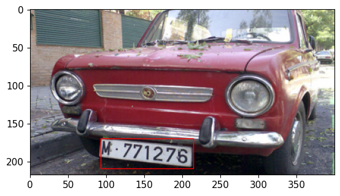

```python
model = torch.hub.load('ultralytics/yolov5', 'custom', path='yolov5/runs/train/exp24/weights/best.pt')
image_path = Image.open('datasets/dataset1/images/test/Cars393.png')
results = model(image_path)

res_tensor = results.xyxy[0]

# convert tensor to normal array
res_numpy = res_tensor.cpu().numpy()

plt.imshow(image_path)
# get the bounding box coordinates
xmin = res_numpy[0][0]
ymin = res_numpy[0][1]
xmax = res_numpy[0][2]
ymax = res_numpy[0][3]

# # draw the bounding box
rect = plt.Rectangle((xmin, ymin),xmax-xmin,ymax-ymin,fill=False,edgecolor='red',linewidth=1)
plt.gca().add_patch(rect)
plt.show()
```

### **Bluring the image using the coordinates acquired from the model**

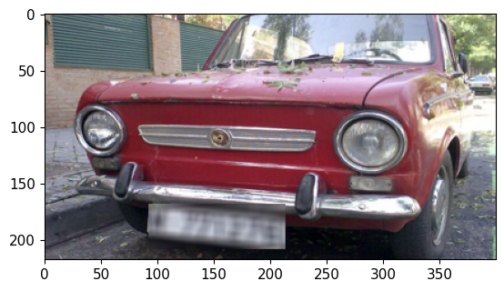

```python
# blur bounding box area
image = cv2.imread('datasets/dataset1/images/test/Cars393.png')
image = cv2.cvtColor(image, cv2.COLOR_BGR2RGB)

# get the bounding box coordinates
xmin = int(res_numpy[0][0])
ymin = int(res_numpy[0][1])
xmax = int(res_numpy[0][2])
ymax = int(res_numpy[0][3])

# blur the image
image[ymin:ymax,xmin:xmax] = cv2.blur(image[ymin:ymax,xmin:xmax],(10,10))

plt.imshow(image)
```

### **Note:** We will later create a function to find and blur the license plate in the image. as well as test it on videos.

### **Observations**

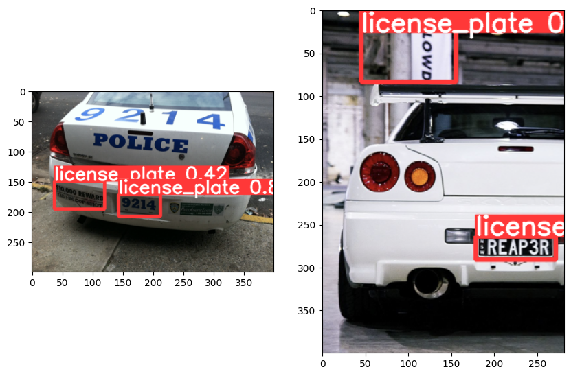

```python
obs_imgs = ["yolov5/runs/detect/exp14/Cars397.png","yolov5/runs/detect/exp14/Cars396.png"]
fig, ax = plt.subplots(1,2,figsize=(10,10))
for i in range(2):
    image = cv2.imread(obs_imgs[i])
    image = cv2.cvtColor(image, cv2.COLOR_BGR2RGB)
    ax[i].imshow(image)
```

Here we can see that text in images are being confused as license plates. resulting in false positives.

# **CCPD2019 Dataset**

This dataset folder is named CCPD2019 in the datasets folder and have following structure:

```
├── CCPD2019
│   ├── ccpd_base
│   ├── ccpd_blur
│   ├── ccpd_challenge
│   ├── ccpd_db
│   ├── ccpd_fn
│   ├── ccpd_np
│   ├── ccpd_rotate
│   ├── ccpd_tilt
│   ├── ccpd_weather
│   ├── splits
│   ├── yolo
│   ├── ├── images
│   ├── ├── labels
```

Some changes are done to the original download, yolo is a folder that is created to store the dataset in required yolo format (using python).  
Here as well labels are aren't provided in the dataset neither are any kind of separate annotation files. it is to be extracted from the image file names.

### **Dataset format (from Github)**

Annotations are embedded in file name.

**Example:** "025-95_113-154&383_386&473-386&473_177&454_154&383_363&402-0_0_22_27_27_33_16-37-15.jpg".  
Each name can be split into seven fields where "-" is present. Those fields are explained as follows.

- **Area (025):** Area ratio of license plate area to the entire picture area.
- **Tilt degree (95,113):** Horizontal tilt degree and vertical tilt degree.
- **Bounding box coordinates:** The coordinates of the left-up and the right-bottom vertices.
- **Four vertices locations:** The exact (x, y) coordinates of the four vertices of LP in the whole image. These coordinates start from the right-bottom vertex.
- **License plate number:** Each image in CCPD has only one LP. Each LP number is comprised of a Chinese character, a letter, and five letters or numbers. A valid Chinese license plate consists of seven characters: province (1 character), alphabets (1 character), alphabets+digits (5 characters). "0_0_22_27_27_33_16" is the index of each character. These three arrays are defined as follows. The last character of each array is letter O rather than a digit 0. We use O as a sign of "no character" because there is no O in Chinese license plate characters.
- **Brightness:** The brightness of the license plate region.
- **Blurriness:** The Blurriness of the license plate region.

### **Dataset split ratio (provided)**

Some information about the dataset split ratio is provided in the splits folder, though it is not in the format required by YOLOv5 and the one we used for training.

```python
# read test, train and val text files from CCPD2019/splits
with open('datasets/CCPD2019/splits/test.txt') as f:
    test_images = f.readlines()
with open('datasets/CCPD2019/splits/train.txt') as f:
    train_images = f.readlines()
with open('datasets/CCPD2019/splits/val.txt') as f:
    val_images = f.readlines()

# remove the new line character from the end of the string
test_images = [x.strip() for x in test_images]
train_images = [x.strip() for x in train_images]
val_images = [x.strip() for x in val_images]

print(f"test images: {len(test_images)}, train images: {len(train_images)}, val images: {len(val_images)}")

total_images = len(test_images) + len(train_images) + len(val_images)
print(f"total images: {total_images}\n")
# get ratios of train, val and test images
train_ratio = len(train_images)/total_images
val_ratio = len(val_images)/total_images
test_ratio = len(test_images)/total_images

print(f"train ratio: {train_ratio}, \nval ratio: {val_ratio}, \ntest ratio: {test_ratio}")
```

```
test images: 141982, train images: 100000, val images: 99996
total images: 341978

train ratio: 0.2924164712349917,
val ratio: 0.29240477457614233,
test ratio: 0.41517875418886596
```

### **Testing the annotations (bounding box coordinates)**

```python
def check_image_bounding_box(image_str):
    xy = []

    test1 = image_str[10:].split("-")
    test1 = test1[2].split("_")

    # convert to x1,y1,x2,y2
    for i in range(len(test1)):
        test1[i] = test1[i].split("&")
        xy.append((int(test1[i][0]),int(test1[i][1])))

    print(xy)
    # get the image and show it with bounding box
    image = cv2.imread('datasets/CCPD2019/'+image_str)
    # get height and width of the image
    h,w = image.shape[:2]
    print(f"height: {h}, width: {w}")
    image = cv2.cvtColor(image, cv2.COLOR_BGR2RGB)

    # get the bounding box coordinates
    xmin = xy[0][0]
    ymin = xy[0][1]
    xmax = xy[1][0]
    ymax = xy[1][1]

    # print x_center,y_center,width,height in ratios
    print(f"x_center: {(xmin+xmax)/2/w},\ny_center: {(ymin+ymax)/2/h},\nwidth: {(xmax-xmin)/w},\nheight: {(ymax-ymin)/h}""")

    # draw the bounding box
    rect = plt.Rectangle((xmin, ymin),xmax-xmin,ymax-ymin,fill=False,edgecolor='red',linewidth=1)
    plt.gca().add_patch(rect)

    # draw a circle in the center of the bounding box
    plt.plot((xmin+xmax)/2,(ymin+ymax)/2,'ro')

    plt.imshow(image)
```

```
ccpd_base/0219683908046-89_84-126&620_414&687-414&688_144&694_122&619_392&613-0_0_1_25_25_26_3-36-29.jpg
[(126, 620), (414, 687)]
height: 1160, width: 720
x_center: 0.375,
y_center: 0.5633620689655172,
width: 0.4,
height: 0.05775862068965517
```

[figure not shown]

```python
print(val_images[0])
check_image_bounding_box(val_images[0])
```

### **Testing annotations (edges)**

```python
def check_image_exact_vertices(image_str):
    xy = []

    test1 = image_str[10:].split("-")
    test1 = test1[3].split("_")

    # convert to x1,y1,x2,y2
    for i in range(len(test1)):
        test1[i] = test1[i].split("&")
        xy.append((int(test1[i][0]),int(test1[i][1])))

    print(xy)

    # [(482, 585), (148, 572), (139, 473), (473, 486)]
    # show these points on the image
    image = cv2.imread('datasets/CCPD2019/'+image_str)
    image = cv2.cvtColor(image, cv2.COLOR_BGR2RGB)

    # show the points on the image
    for i in range(len(xy)):
        # show the points bigger
        cv2.circle(image, xy[i], 10, (0, 0, 255), -1)

    plt.imshow(image)
```

```
[(482, 585), (148, 572), (139, 473), (473, 486)]
```

[figure not shown]

```python
check_image_exact_vertices(val_images[3])
```

### **Check number of images given in splits *.txt file**

```python
# while the ccpd does have train, val and test splits,it is of 30%, 30%, 40% respectively.
# so we will create our own splits with more images in the train set.
# lets remove ccpd_np as it does not have bounding boxes
all_images = []

# loop through datasets/CCPD2019/splits files
for file in os.listdir('datasets/CCPD2019/splits'):
    if "test" not in file and "train" not in file and "val" not in file:
        with open('datasets/CCPD2019/splits/'+file) as f:
            images = f.readlines()
        # remove the new line character from the end of the string
        images = [x.strip() for x in images]
        print(f"{file}: {len(images)}")
        all_images.extend(images)

print(f"total images: {len(all_images)}")
```

```
ccpd_blur.txt: 20611
ccpd_challenge.txt: 50003
ccpd_db.txt: 10132
ccpd_fn.txt: 20967
ccpd_rotate.txt: 10053
ccpd_tilt.txt: 30216
total images: 141982
```

#### **Note:** we won't be using the train, val and test splits provided by the CCPD2019 dataset. We will be creating our own splits.

### **Check number of images in folders**

```python
images_count = 0
# loop through datasets/CCPD2019
for file in os.listdir('datasets/CCPD2019'):
    # check if the file is a directory
    if os.path.isdir('datasets/CCPD2019/'+file) and file!="splits" and file!="ccpd_np" and file!="yolo":
        # add length of the directory to images_count
        print(f"{file}: {len(os.listdir('datasets/CCPD2019/'+file))}")
        images_count += len(os.listdir('datasets/CCPD2019/'+file))

print()
print(f"Total Images: {images_count}")
```

```
ccpd_base: 199996
ccpd_blur: 20611
ccpd_challenge: 50003
ccpd_db: 10132
ccpd_fn: 20967
ccpd_rotate: 10053
ccpd_tilt: 30216
ccpd_weather: 9999

Total Images: 351977
```

## **Preparing Data**

### **Creating a dictionary of folders and images**

```python
# splitting the images into train, val and test with 60%, 20%, 20% ratio
# for each of the folders in CCPD2019

images_folders = []

# loop through datasets/CCPD2019
for file in os.listdir('datasets/CCPD2019'):
    # check if the file is a directory
    if os.path.isdir('datasets/CCPD2019/'+file) and file!="splits" and file!="ccpd_np":
        images_folders.append(file)

print(images_folders)

# create a dictionary with the folder name as key and the list of images as value
images_dict = {}

# loop through the images folders
for folder in images_folders:
    images = []
    # loop through the images in the folder
    for file in os.listdir('datasets/CCPD2019/'+folder):
        images.append('datasets/CCPD2019/'+folder+'/'+file)
    images_dict[folder] = images

# print total length of all folder in the dictionary
print(f"total images in dictionary: {sum([len(images_dict[x]) for x in images_dict])}")
```

```
['ccpd_base', 'ccpd_blur', 'ccpd_challenge', 'ccpd_db', 'ccpd_fn', 'ccpd_rotate', 'ccpd_tilt', 'ccpd_weather', 'yolo']
total images in dictionary: 351979
```

### **Splitting the dataset in 60:20:20 ratio**

```python
# We need to split the images into train, val and test with 60%, 20%, 20% ratio for each of the folders in CCPD2019
# using the images_dict dictionary
train_images_dirs = []
val_images_dirs = []
test_images_dirs = []

# loop through the images dictionary
for folder in images_dict:
    # get the length of the images in the folder
    images_len = len(images_dict[folder])
    # get the train, val and test split
    train_split = int(images_len*0.6)
    val_split = int(images_len*0.2)
    test_split = int(images_len*0.2)

    # get the train, val and test images
    train_images = images_dict[folder][:train_split]
    val_images = images_dict[folder][train_split:train_split+val_split]
    test_images = images_dict[folder][train_split+val_split:]

    # append the train, val and test images to the train_images_dirs, val_images_dirs and test_images_dirs
    train_images_dirs.extend(train_images)
    val_images_dirs.extend(val_images)
    test_images_dirs.extend(test_images)

print(f"train images: {len(train_images_dirs)}")
print(f"val images: {len(val_images_dirs)}")
print(f"test images: {len(test_images_dirs)}\n")

# verify the total number of images
print(f"total images: {len(train_images_dirs)+len(val_images_dirs)+len(test_images_dirs)}")
```

```
train images: 211183
val images: 70392
test images: 70404

total images: 351979
```

### **Copying the images to the respective folders (Yolo format)**

```python
# create folders for train, val and test images in CCPD2019 folder
# and copy the images to the respective folders

# create train folder
if not os.path.exists('datasets/CCPD2019/yolo/images/train'):
    os.makedirs('datasets/CCPD2019/yolo/images/train')

# create val folder
if not os.path.exists('datasets/CCPD2019/yolo/images/val'):
    os.makedirs('datasets/CCPD2019/yolo/images/val')

# create test folder
if not os.path.exists('datasets/CCPD2019/yolo/images/test'):
    os.makedirs('datasets/CCPD2019/yolo/images/test')

# loop through the train images
for image in train_images_dirs:
    # copy the image to the train folder
    shutil.copy(image, 'datasets/CCPD2019/yolo/images/train')
    # status bar percentage
    print(f"Copying train images: {round((train_images_dirs.index(image)/len(train_images_dirs))*100, 2)}%", end="\r")

print()
print("_"*50)
# loop through the val images
for image in val_images_dirs:
    # copy the image to the val folder
    shutil.copy(image, 'datasets/CCPD2019/yolo/images/val')
    print(f"Copying val images: {round((val_images_dirs.index(image)/len(val_images_dirs))*100, 2)}%", end="\r")

print()
print("_"*50)
# loop through the test images
for image in test_images_dirs:
    # copy the image to the test folder
    shutil.copy(image, 'datasets/CCPD2019/yolo/images/test')
    print(f"Copying test images: {round((test_images_dirs.index(image)/len(test_images_dirs))*100, 2)}%", end="\r")
```

### **Creating labels (*.txt files)**

Creating Labels was very slow, coming around 7hrs+ if done in a single run as a loop.  
So to speed up the process, I used multiprocessing to create the labels in parallel in batches of 1000.  
Since I have a 16 core CPU, I used 12 processes to create the labels. theoretically reducing the time by a factor of 12.

#### **Multiprocessing check**

```python
import multiprocessing
# print number of cpu cores
print(f"Number of CPU cores: {multiprocessing.cpu_count()}")
```

```
Number of CPU cores: 16
```

#### **Creating folders and labels**

Here I faced a problem with jupyter notebook and multiprocessing.  
The problems/bugs are well known and workarounds were cumbersome.  
So I decided to write code in a separate python file and call it from notebook  
The code is written in a file `processBatch.py` and contains following code:

```
from PIL import Image

def process_batch(batch):
    for image_dir, image in batch:
        # get the image name
        image_name = image.split("/")[-1]
        # get the image width and height
        image_width, image_height = Image.open(image_dir+"/"+image).size
        # get the image label
        image_label = (image_dir+"/"+image).replace("images", "labels").replace(".jpg", ".txt")
        # get the image label name
        image_label_name = image_label.split("/")[-1]
        # break the image name into parts
        image_name_parts = image_name.split("-")
        xy = []
        for i in range(len(image_name_parts[2].split("_"))):
            xy.append(image_name_parts[2].split("_")[i].split("&"))
            xy = [list(map(int, x)) for x in xy]
        # get bounding box coordinates
        xmin = xy[0][0]
        ymin = xy[0][1]
        xmax = xy[1][0]
        ymax = xy[1][1]

        # print x_center, y_center, width, height in ratios
        x_center = (xmin + xmax) / (2 * image_width)
        y_center = (ymin + ymax) / (2 * image_height)
        width = (xmax - xmin) / image_width
        height = (ymax - ymin) / image_height
        # write the bounding box coordinates to the txt file
        with open(image_label, "w") as f:
            f.write(f"0 {x_center} {y_center} {width} {height}")

        # close the file
        f.close()

        print(f"Creating labels {image_dir.split('/')[-1]}")
```

It used the same formulas as above to convert the bounding box coordinates to ratios.  
The formulas are as follows

- The x_center and y_center are calculated by the formula:  
  `x_center = (xmin + xmax)/(2*tw)`  
  `y_center = (ymin + ymax)/(2*th)`
- The width and height of the bounding box are calculated by the formula:  
  `width = (xmax - xmin)/tw`  
  `height = (ymax - ymin)/th`

note: where tw and th are the width and height of the image respectively.

```python
import os
import multiprocessing
import processBatch

if __name__ == '__main__':
    # create a folder called labels in CCPD2019/yolo
    if not os.path.exists('datasets/CCPD2019/yolo/labels'):
        os.makedirs('datasets/CCPD2019/yolo/labels')

    # create train folder
    if not os.path.exists('datasets/CCPD2019/yolo/labels/train'):
        os.makedirs('datasets/CCPD2019/yolo/labels/train')

    # create val folder
    if not os.path.exists('datasets/CCPD2019/yolo/labels/val'):
        os.makedirs('datasets/CCPD2019/yolo/labels/val')

    # create test folder
    if not os.path.exists('datasets/CCPD2019/yolo/labels/test'):
        os.makedirs('datasets/CCPD2019/yolo/labels/test')

    images_dir = []
    for dirs in os.listdir('datasets/CCPD2019/yolo/images'):
        images_dir.append('datasets/CCPD2019/yolo/images/'+dirs)

    # create a pool of worker processes
    pool = multiprocessing.Pool(processes=12)

    batch_size = 1000
    for image_dir in images_dir:
        image_files = os.listdir(image_dir)
        num_batches = len(image_files) // batch_size + 1
        for i in range(num_batches):
            batch_start = i * batch_size
            batch_end = (i + 1) * batch_size
            batch = [(image_dir, image_files[j]) for j in range(batch_start, batch_end) if j < len(image_files)]
            # submit each image and its directory to the process pool
            pool.apply_async(processBatch.process_batch, args=(batch,))

    # close the pool and wait for all processes to complete
    pool.close()
    pool.join()

    print("Done")
```

```
Done
```

Either bug or intended behavior, but jupyter notebook doesn't show the progress bar of the training process. So, I ran the training process in a terminal.  
The training process is done in the terminal using the following command:

> ```
> !python yolov5/train.py --img 640 --batch 8 --epochs 3 --data ccpd.yaml --weights yolov5s.pt --device 0
> ```

**parameters used:**

- `--img 640` : image size
- `--batch 8` : batch size
- `--epochs 3` : number of epochs
- `--data ccpd.yaml` : path to the dataset configuration file
- `--weights yolov5s.pt` : path to the pretrained weights
- `--device 0` : device to use for training (GPU here)

### **Training the model**

```python
!python yolov5/train.py --img 640 --batch 8 --epochs 3 --data ccpd.yaml --weights yolov5s.pt --device 0
```

#### **Note:** We won't be testing using detect.py script as there are many images in the test set.

### **Observations**

- This model is much resource intensive than the previous one due to the sheer number of images in the dataset. each epoch taking around 1hr to complete.
- The model was trained for 3 epochs any more resulted in very little improvement.
- We are limited by the local machine resources and the time taken to train the model. system would be unusable for other tasks during the time (uses all the RAM).
- Many different variations were tried and most optimal is chosen, batch size 8 makes it slightly faster, 16 much more but either crashes the system or break's display drivers.
- But again this dataset resulted in almost similar result with just 3 epochs compared to previous dataset trained for 100 epochs.

# **Testing using the trained models**

It's time to create proper function's to detect and blur license plates in an image and video without needing to run the detect.py script.  
It's important to make the function as versatile as possible so that it can be used in various scenarios.

### **Function to detect license plates in an image**

```python
import torch
from PIL import Image
%matplotlib inline
import matplotlib.pyplot as plt
import cv2

def detect_and_blur_number_plates(model, image, blur_size = 10, show_image=False, image_is_path=False, color = False):

    if image_is_path:
        image_path = image
        image = Image.open(image)

    results = model(image)
    if len(results.xyxy[0]) == 0:
        # show the image
        if show_image:
            # plot title
            plt.title("No license plates detected")
            plt.imshow(image)
            plt.show()
        return image
    res_tensor = results.xyxy[0]

    # convert tensor to normal array
    res_numpy = res_tensor.cpu().numpy()

    image_to_blur = None
    # loop through all detected license plates and blur each one
    for bbox in res_numpy:
        xmin = int(bbox[0])
        ymin = int(bbox[1])
        xmax = int(bbox[2])
        ymax = int(bbox[3])
        # cv2 reads image in BGR format
        if image_is_path:
            image_to_blur = cv2.imread(image_path)
            image_to_blur = cv2.cvtColor(image_to_blur, cv2.COLOR_BGR2RGB)
        else:
            image_to_blur = image.copy()

        if color:
            # fill with red color
            image_to_blur[ymin:ymax,xmin:xmax] = color
        else:
            # blur the image
            image_to_blur[ymin:ymax,xmin:xmax] = cv2.blur(image_to_blur[ymin:ymax,xmin:xmax],(blur_size,blur_size))

    if show_image:
        fig, (ax1,ax2) = plt.subplots(1, 2, figsize=(10, 5), sharey=True)
        ax1.imshow(image)
        rect = plt.Rectangle((xmin, ymin),xmax-xmin,ymax-ymin,fill=False,edgecolor='red',linewidth=1)
        ax1.add_patch(rect)
        ax1.set_title('Original Image')
        ax2.imshow(image_to_blur)
        ax2.set_title('Blurred Image')
        plt.show()

    return image_to_blur
```

#### **Model is passed outside the function to avoid loading the model again and again.**

```
Using cache found in C:\Users\shiva/.cache\torch\hub\ultralytics_yolov5_master
YOLOv5  2023-2-19 Python-3.10.4 torch-1.13.1+cu117 CUDA:0 (NVIDIA GeForce RTX 3070 Laptop GPU, 8192MiB)

Fusing layers...
Model summary: 157 layers, 7012822 parameters, 0 gradients, 15.8 GFLOPs
Adding AutoShape...
```

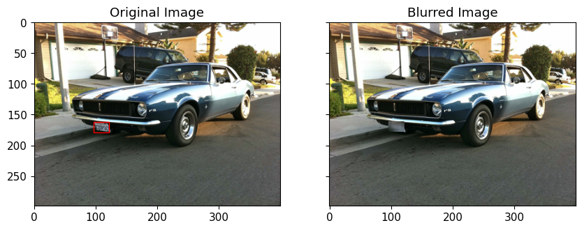

```python
# model is passed outside the function to avoid loading the model again and again
model = torch.hub.load('ultralytics/yolov5', 'custom', path='best_100.pt')

image_path = 'datasets/dataset1/images/test/Cars421.png'
blur_size = 10

image = detect_and_blur_number_plates(model, image_path, blur_size, show_image=True, image_is_path=True)
```

[figure not shown]

```python
# one another
image_path = 'datasets/dataset1/images/test/Cars412.png'
image = detect_and_blur_number_plates(model, image_path, blur_size, show_image=True, image_is_path=True)
```

### **Function to detect license plates in a video**

```python
def blur_number_plates_in_video(model, video_path, output_video_path, blur_size = 10,  color = False, real_time=False):

    # Load the input video file
    cap = cv2.VideoCapture(video_path)
    print(cap.get(3), cap.get(4))
    # Define the output video codec and size
    fourcc = cv2.VideoWriter_fourcc(*'mp4v')
    out = cv2.VideoWriter(output_video_path, fourcc, 30, (int(cap.get(3)), int(cap.get(4))))

    # get the number of frames in the video
    num_frames = int(cap.get(cv2.CAP_PROP_FRAME_COUNT))
    print("Number of frames in the video: {}".format(num_frames))
    # Loop through each frame of the video
    while(cap.isOpened()):
        # show the progress of the video
        print("Processing frame {}/{}".format(int(cap.get(1)), num_frames), end="\r")

        ret, frame = cap.read()
        if ret == True:
            # Pass the frame through your model to detect number plates
            # and blur the region
            processed_frame = detect_and_blur_number_plates(model, frame, blur_size, color=color)

            # Check if the processed frame is not None before writing to the output video, else write the original frame
            if processed_frame is not None:
                # Write the processed frame to the output video file
                out.write(processed_frame)

                # Display the processed frame if you want to see it in real-time
                if real_time:
                    cv2.imshow('Live output', processed_frame)
                    if cv2.waitKey(1) & 0xFF == ord('q'):
                        break
            else:
                # Write the original frame to the output video file
                out.write(frame)

                # Display the original frame if you want to see it in real-time
                cv2.imshow('Live output', frame)
                if cv2.waitKey(1) & 0xFF == ord('q'):
                    break
        else:
            break

    # Release the video capture and writer objects
    cap.release()
    out.release()

    # Close all windows
    cv2.destroyAllWindows()

    # Print the message
    print()
    print("Video processing complete")
```

```python
blur_number_plates_in_video(model, "test_videos/0318.mp4", "test_videos/output/output_singapore_720p_dataset1.mp4", color=(0,0,255), real_time=True)
```

```
1280.0 720.0
Number of frames in the video: 4684
Processing frame 4684/4684
Video processing complete
```

# **Video Result Observations**

> Output video files are available here [Google Drive](https://drive.google.com/drive/folders/1Fm4Rnj7Gu8G5PPf-NkJbl7OfZiacBRKR?usp=sharing)

# **Whats next?**

**License Plate Generation**

Instead of simply blurring the detected license plates, we are interested to explore different options to generate fake license plates that look real. We can use these generated license plates to replaced the detected ones in order to address the privacy issues. Compared to blurring the license plates, replacing them with the fake ones can make the images look more natural. We are considering a few different appraoches to address this problem, including autoencoders and GANs.

**Consistent Detections in Videos**

First, we may consider the sequential non-maximum suppression [(Seq-NMS)](https://arxiv.org/pdf/1602.08465.pdf). Non-maximum suppression is an essential component in YOLOv3 to remove redundant bounding box predictions. Seq-NMS adopts a similar idea, but it is applied to multiple frames in a video clip to remove unncessary box predictions while taking the predictions at different time steps into account. This approach is relatively easy to be integrated into our current pipeline.

Another approach is to design a neural network to enforce the temporal consistency. To adopt this approach, we will need to find a training loss to enforce temporal consistency between different detected objects. We will need to find a video datset with license plate labels. However, this may be addressed by applying appropriate projective transformations to images in our current dataset carefully. With the proper transformations and cropping, we may be able to create multiple frames from one training image such that these frames look like they are from the same video clip. We may also need to design a network to exploit all information from different frames. This may be achieved by using RNN or 3D convolution. However, training these models may be too time-consuming given the amount of time we have left.